# Trait Analysis for Body Comp and biomarkers by SNPs related to 7 cardiometabolic health, WHITES ONLY

M. Newell

3/16/2020

```r
library(tidyverse)
```

Create final dataset and split into male and female dataset

```r
#load main dataset
load('/rsgrps/yann/michellenewell/UKB/Full_dataset/Main_dataset_UKB_n487320_derived variables_20191014_mdat.rda')
dim(mdat)
```

```
## [1] 487320   4116
```

Exclude withdrawals and non-whites

```r
#Exclude people no longer participating
table(mdat$f.eid < 0)
```

```
##
##  FALSE
## 487320
```

```r
excl <- read.table('/rsgrps/yann/UKBIOBANK/Download/PeopleToExclude/w15678_20200204.csv', header=F)
sum(mdat$f.eid %in% excl$V1)
```

```
## [1] 23
```

```r
#hetero outliers, none in dataset
table(mdat$het.missing.outliers)
```

```
##
##      0
## 487320
```

```r
#Genetic exclusions, White only
sum(mdat$GenExcl3 == 1)
```

```
## [1] 28432
```

```r
#Subset with all exclusions
mdat_excl <- mdat %>%
  filter(!(f.eid %in% excl$V1), !(GenExcl3 == 1))
dim(mdat_excl)
```

```
## [1] 458866   4116
```

```r
#Check
sum(!(mdat_excl$GenExcl3 == 1) & !(mdat_excl$f.eid %in% excl$V1))
```

```
## [1] 458866
```

Merge SNPs into main file, will only merge whit only participants

```r
#______________________Merge__________________________________________________________
#Combine 4 SNPs with phenotype data
setwd('/rsgrps/yann/michellenewell/UKB/PheWAS/7Traits_4SNPs_20190909/xData')
snps <- read.csv('TraitsOfInterest_SNPs_7Cardio_n478320_updated5snps_20191108.csv', header = T)

all.equal(snps$userId, mdat$f.eid)
```

```
## [1] TRUE
```

```r
#[1] TRUE

mdat2 <- merge(mdat_excl, snps[, c("userId", "rs13389219_T", "snp7_130438531_C", "rs5792311_C", "rs8126001_T", "rs998584_A")], by.x = "f.eid", by.y = "userId")
dim(mdat2)
```

```
## [1] 458866   4121
```

```r
#rs13389219_T and rs998584_A already in data set, merged column from snps dataset ends in '.y' - I will use this variable
```

```r
rm(mdat)
rm(mdat_excl)
rm(snps)
rm(excl)
```

SNP columns and duplicates

```r
colnames(mdat2)[4117:4121]
```

```
## [1] "rs13389219_T.y"   "snp7_130438531_C" "rs5792311_C"
## [4] "rs8126001_T"      "rs998584_A.y"
```

```r
all.equal(mdat2$rs13389219_T.x, mdat2$rs13389219_T.y)
```

```
## [1] TRUE
```

```r
all.equal(mdat2$rs998584_A.x, mdat2$rs998584_A.y)
```

```
## [1] TRUE
```

#Create variables (ALT, CRP, LEGFAT %), inverse normalize all vars of interest, and stratify by Sex

Create ALT with exclusions for liver disease, certain medications, and high alcohol use

Exclude liver disease/problems 1. UKB, Non-cancer field(20002) 1155 hepatitis 1156 infective/viral hepatitis 1157 non-infective hepatitis 1158 liver failure/cirrhosis 1159 bile duct disease 1160 bile duct obstruction/ascending cholangitis 1161 gall bladder disease 1162 cholelithiasis/gall stones 1163 cholecystitis 1164 pancreatic disease 1165 pancreatitis 1339 sickle cell disease 1340 thalassaemia 1439 hiv/aids 1506 p-biliary-cirrhosis 1578 hepatitis a 1579 hepatitis b 1580 hepatitis c 1581 hepatitis d 1582 hepatitis e 1604 alcoholic liver disease / alcoholic cirrhosis

2. UKB, Cancer field(20001) 1047 lymphoma 1048 leukaemia 1050 multiple myeloma 1051 myelofibrosis or myelodysplasia 1052 hodgkins lymphoma / hodgkins disease 1053 non-hodgkins lymphoma 1055 chronic lymphocytic Yes 1056 chronic myeloid 1058 other haematological malignancy

```r
#Loops to calculate people with liver illness

# 1. Liver disease codes, non-cancer
X1 <- c("1155", "1156", "1157", "1158", "1159", "1160", "1161", "1162", "1163", "1164", "1165",
     "1339", "1340", "1439", "1506", "1578", "1579", "1580", "1581", "1582", "1604")

l1 <- rep(0, nrow(mdat2))
g1 <- c()

grep("f.20002.0.", names(mdat2)) # 2783-2811
```

```
##  [1] 2783 2784 2785 2786 2787 2788 2789 2790 2791 2792 2793 2794 2795 2796
## [15] 2797 2798 2799 2800 2801 2802 2803 2804 2805 2806 2807 2808 2809 2810
## [29] 2811
```

```r
for(i in c(2783:2811)){
  g1 <- ifelse(mdat2[, i] %in% X1, 1, 0)
  l1 <- g1 + l1
  print(i)
}
```

```
## [1] 2783
## [1] 2784
## [1] 2785
## [1] 2786
## [1] 2787
## [1] 2788
## [1] 2789
## [1] 2790
## [1] 2791
## [1] 2792
## [1] 2793
## [1] 2794
## [1] 2795
## [1] 2796
## [1] 2797
## [1] 2798
## [1] 2799
## [1] 2800
## [1] 2801
## [1] 2802
## [1] 2803
## [1] 2804
## [1] 2805
## [1] 2806
## [1] 2807
## [1] 2808
## [1] 2809
## [1] 2810
## [1] 2811
```

```r
table(l1)
```

```
## l1
##      0      1      2      3
## 446721  11621    508     16
```

```r
mdat2$HepDis1 <- ifelse(l1 >= 1, 1, 0)
table(mdat2$HepDis1)
```

```
##
##      0      1
## 446721  12145
```

```r
# 2. Liver cancer codes
X2 <- c("1047", "1048", "1050", "1051", "1052", "1053", "1055", "1056", "1058")

l2 <- rep(0, nrow(mdat2))
g2 <- c()

grep("f.20001.0.", names(mdat2))
```

```
## [1] 2765 2766 2767 2768 2769 2770
```

```r
#[1] 2765 2766 2767 2768 2769 2770
```

```r
for(i in c(2765:2770)){
  g2 <- ifelse(mdat2[, i] %in% X2, 1, 0)
  l2 <- g2 + l2
  print(i)
}
```

```
## [1] 2765
## [1] 2766
## [1] 2767
## [1] 2768
## [1] 2769
## [1] 2770
```

```r
table(l2)
```

```
## l2
##      0      1      2
## 456621   2227     18
```

```r
mdat2$HepDis2 <- ifelse(l2 >= 1, 1, 0)
table(mdat2$HepDis2)
```

```
##
##      0      1
## 456621   2245
```

```r
# 3. Taking medication for liver disease
# amiodarone,prednisolone,methylprednisolone
Y <-c("1140888502", "1140868364", "1140874976")

l3 <- rep(0, nrow(mdat2))
g3 <- c()

grep("f.20003.0.", names(mdat2))#2055:2102
```

```
##  [1] 2055 2056 2057 2058 2059 2060 2061 2062 2063 2064 2065 2066 2067 2068
## [15] 2069 2070 2071 2072 2073 2074 2075 2076 2077 2078 2079 2080 2081 2082
## [29] 2083 2084 2085 2086 2087 2088 2089 2090 2091 2092 2093 2094 2095 2096
## [43] 2097 2098 2099 2100 2101 2102 2870 2871 2872 2873 2874 2875 2876 2877
## [57] 2878 2879 2880 2881 2882 2883 2884 2885 2886 2887 2888 2889 2890 2891
## [71] 2892 2893 2894 2895 2896 2897 2898 2899 2900 2901 2902 2903 2904 2905
## [85] 2906 2907 2908 2909 2910 2911 2912 2913 2914 2915 2916 2917
```

```r
for(i in c(2055:2102)){
  g3 <- ifelse(mdat2[, i] %in% Y, 1, 0)
  l3 <- g3 + l3
  print(i)
}
```

```
## [1] 2055
## [1] 2056
## [1] 2057
## [1] 2058
## [1] 2059
## [1] 2060
## [1] 2061
## [1] 2062
## [1] 2063
## [1] 2064
## [1] 2065
## [1] 2066
## [1] 2067
## [1] 2068
## [1] 2069
```

[output cut: 33 more lines]

```r
table(l3)
```

```
## l3
##      0      1      2
## 458182    683      1
```

```r
mdat2$HepMeds <- ifelse(l3 >= 1, 1, 0)
table(mdat2$HepMeds)
```

```
##
##      0      1
## 458182    684
```

```r
rm(l1)
rm(l2)
rm(l3)
rm(g1)
rm(g2)
rm(g3)
rm(X1)
rm(X2)
rm(Y)
```

Alcohol consumption

```r
#Units per week, based on number and types of drinks
#wine
mdat2$WineAvgUnitWk <- NA
mdat2$WineAvgUnitWk <- ifelse((mdat2$f.1568.0.0 < 0 | mdat2$f.1578.0.0 < 0), NA,
                         (mdat2$f.1568.0.0*2 + mdat2$f.1578.0.0*2))
#beer/cider
mdat2$BeerAvgUnitWk <- NA
mdat2$BeerAvgUnitWk <- ifelse(mdat2$f.1588.0.0 < 0, NA, mdat2$f.1588.0.0*2.5)
#spirits
mdat2$SpiritsAvgUnitWk <- NA
mdat2$SpiritsAvgUnitWk <- ifelse(mdat2$f.1598.0.0 < 0, NA, mdat2$f.1598.0.0)

summary(mdat2$WineAvgUnitWk)
```

```
##    Min. 1st Qu.  Median    Mean 3rd Qu.    Max.    NA's
##    0.00    4.00   10.00   13.24   18.00  480.00  134793
```

```r
summary(mdat2$BeerAvgUnitWk)
```

```
##    Min. 1st Qu.  Median    Mean 3rd Qu.    Max.    NA's
##    0.00    0.00    2.50    7.57   10.00  525.00  133257
```

```r
summary(mdat2$SpiritsAvgUnitWk)
```

```
##    Min. 1st Qu.  Median    Mean 3rd Qu.    Max.    NA's
##    0.00    0.00    0.00    1.83    2.00  250.00  134312
```

```r
#Never = 6, Spec Occasion Only = 5, 1-3/mo = 4
mdat2$AlcUnitsRaw <- NA
mdat2$AlcUnitsRaw <- ifelse ((mdat2$f.1558.0.0 == 6 | mdat2$f.1558.0.0 == 5 | mdat2$f.1558.0.0 == 4), 0,
                              (mdat2$WineAvgUnitWk + mdat2$BeerAvgUnitWk + mdat2$SpiritsAvgUnitWk))
summary(mdat2$AlcUnitsRaw)
```

```
##    Min. 1st Qu.  Median    Mean 3rd Qu.    Max.    NA's
##    0.00    0.00   11.00   16.04   24.00  855.00    5330
```

```r
#Exclude > 5 SD, males > 104, females > 89
cutoff <- mean(mdat2$AlcUnitsRaw, na.rm = T) + 5*sd(mdat2$AlcUnitsRaw, na.rm = T)
cutoff
```

```
## [1] 113.3666
```

```r
mdat2$AlcUnitsPerWk <- ifelse(((mdat2$Sex == 0 & mdat2$AlcUnitsRaw > 89) |
                               (mdat2$Sex == 1 & mdat2$AlcUnitsRaw > 102) |
                                 (mdat2$AlcUnitsRaw > cutoff)), NA, mdat2$AlcUnitsRaw)
summary(mdat2$AlcUnitsPerWk)
```

```
##    Min. 1st Qu.  Median    Mean 3rd Qu.    Max.    NA's
##    0.00    0.00   11.00   15.46   24.00  102.00    7682
```

Dataset with additional derived variables

```r
#LegFat %, average of left and right
 final <- mdat2 %>%
  mutate(legFatPerc = (mdat2$f.23115.0.0 + mdat2$f.23111.0.0)/2,
         CRP_excl10 = ifelse(mdat2$f.30710.0.0 < 10, mdat2$f.30710.0.0, NA),
         ALT_MultExcl = ifelse((mdat2$HepDis1 == 1 | mdat2$HepDis2 == 1 |mdat2$HepMeds == 1 |
                                mdat2$AlcUnitsPerWk > 14), NA, mdat2$f.30620.0.0))

summary(final$legFatPerc)
```

```
##    Min. 1st Qu.  Median    Mean 3rd Qu.    Max.    NA's
##    1.45   22.25   33.15   31.94   40.95   67.25    8042
```

```r
summary(final$CRP_excl10)
```

```
##    Min. 1st Qu.  Median    Mean 3rd Qu.    Max.    NA's
##    0.08    0.63    1.26    1.90    2.48    9.99   40281
```

```r
summary(final$f.30710.0.0)
```

```
##    Min. 1st Qu.  Median    Mean 3rd Qu.    Max.    NA's
##   0.080   0.660   1.330   2.591   2.750  79.960   22294
```

```r
summary(final$ALT_MultExcl)
```

```
##    Min. 1st Qu.  Median    Mean 3rd Qu.    Max.    NA's
##    3.01   14.82   19.16   22.30   25.82  491.03  212987
```

Stratify by Sex for final datasets

```r
female <- final %>%
  filter(Sex == 0)
dim(female)
```

```
## [1] 249147   4132
```

```r
male <- final %>%
  filter(Sex == 1)
dim(male)
```

```
## [1] 209719   4132
```

```r
rm(final)
```

```r
rm(mdat2)
```

Then, inverse normalize all body compositions and ALT of interest for female and male

```r
#INVERSE NORMALIZATION
my.invnorm = function(x)
{
  res = rank(x)
  res = qnorm(res/(length(res)+0.5))
  return(res)
}

#female, InvNorm BMI
female$InvNorm_BMI[!is.na(female$f.21001.0.0)] <- my.invnorm(female$f.21001.0.0[!is.na(female$f.21001.0.0)])
#female, InvNorm WC
female$InvNorm_WC[!is.na(female$f.48.0.0)] <- my.invnorm(female$f.48.0.0[!is.na(female$f.48.0.0)])
#female, InvNorm HC
female$InvNorm_HC[!is.na(female$f.49.0.0)] <- my.invnorm(female$f.49.0.0[!is.na(female$f.49.0.0)])
#female, InvNorm legfat
female$InvNorm_LegFatPerc[!is.na(female$legFatPerc)] <- my.invnorm(female$legFatPerc[!is.na(female$legFatPerc)])
#female, InvNorm bodyFat
female$InvNorm_BodyFatPerc[!is.na(female$f.23099.0.0)] <- my.invnorm(female$f.23099.0.0[!is.na(female$f.23099.0.0)])
#female, InvNorm ALT
female$InvNorm_ALT_MultExcl[!is.na(female$ALT_MultExcl)] <- my.invnorm(female$ALT_MultExcl[!is.na(female$ALT_MultExcl)])
#female, InvNorm CRP
female$InvNorm_CRP[!is.na(female$CRP_excl10)] <- my.invnorm(female$CRP_excl10[!is.na(female$CRP_excl10)])


#male, InvNorm BMI
male$InvNorm_BMI[!is.na(male$f.21001.0.0)] <- my.invnorm(male$f.21001.0.0[!is.na(male$f.21001.0.0)])
#male, InvNorm WC
male$InvNorm_WC[!is.na(male$f.48.0.0)] <- my.invnorm(male$f.48.0.0[!is.na(male$f.48.0.0)])
#male, InvNorm HC
male$InvNorm_HC[!is.na(male$f.49.0.0)] <- my.invnorm(male$f.49.0.0[!is.na(male$f.49.0.0)])
#male, InvNorm legfat
male$InvNorm_LegFatPerc[!is.na(male$legFatPerc)] <- my.invnorm(male$legFatPerc[!is.na(male$legFatPerc)])
#male, InvNorm bodyFat
male$InvNorm_BodyFatPerc[!is.na(male$f.23099.0.0)] <- my.invnorm(male$f.23099.0.0[!is.na(male$f.23099.0.0)])
#male, InvNorm ALT
male$InvNorm_ALT_MultExcl[!is.na(male$ALT_MultExcl)] <- my.invnorm(male$ALT_MultExcl[!is.na(male$ALT_MultExcl)])
#male, InvNorm CRP
male$InvNorm_CRP[!is.na(male$CRP_excl10)] <- my.invnorm(male$CRP_excl10[!is.na(male$CRP_excl10)])
```

Observe distributions

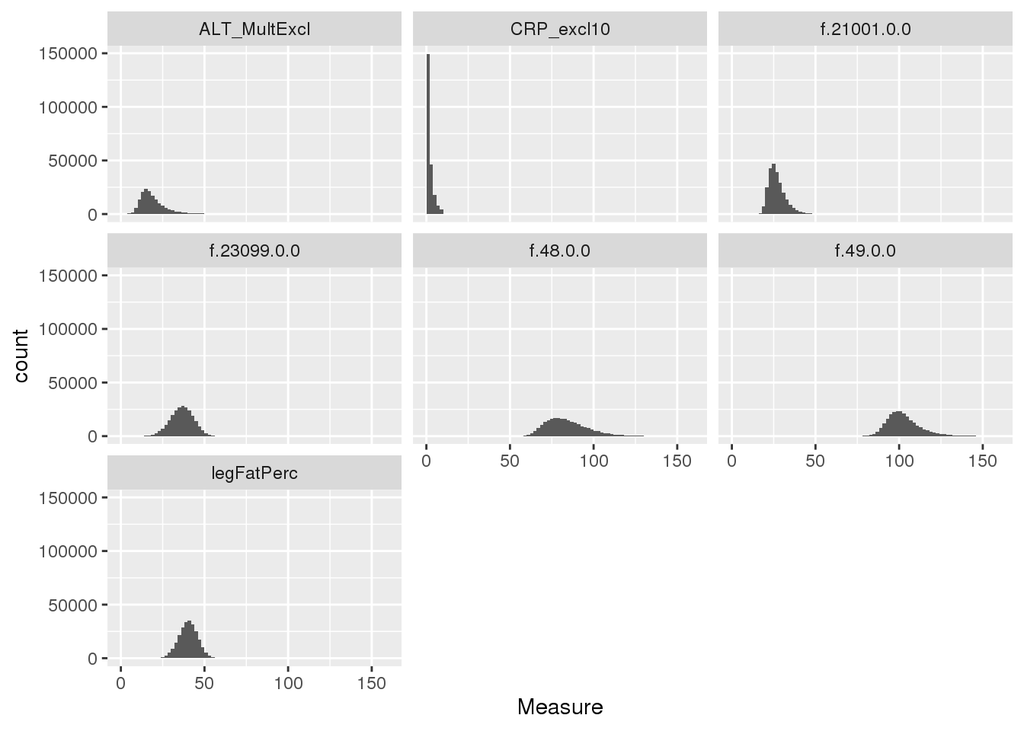

```r
#Histgrams, raw -  female
female %>%
  select(f.21001.0.0, f.48.0.0, f.49.0.0, legFatPerc, f.23099.0.0, ALT_MultExcl, CRP_excl10) %>%
  gather(key = BodyComp, value = Measure) %>%
  ggplot(aes(x = Measure)) +
  geom_histogram(breaks = seq(0, 160, by = 2)) +
  facet_wrap(~BodyComp)
```

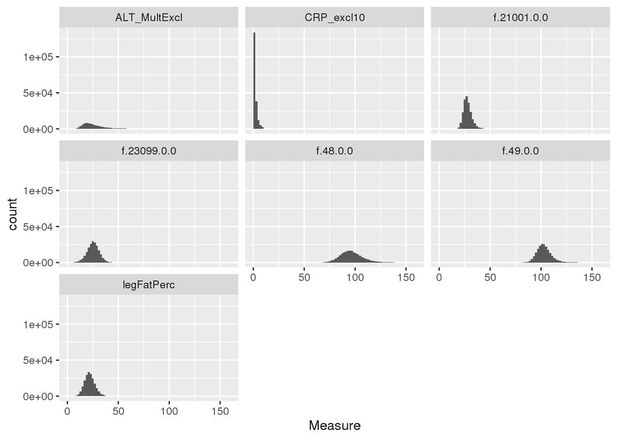

```r
#Histgrams, raw -  male
male %>%
  select(f.21001.0.0, f.48.0.0, f.49.0.0, legFatPerc, f.23099.0.0, ALT_MultExcl, CRP_excl10) %>%
  gather(key = BodyComp, value = Measure) %>%
  ggplot(aes(x = Measure)) +
  geom_histogram(breaks = seq(0, 160, by = 2)) +
  facet_wrap(~BodyComp)
```

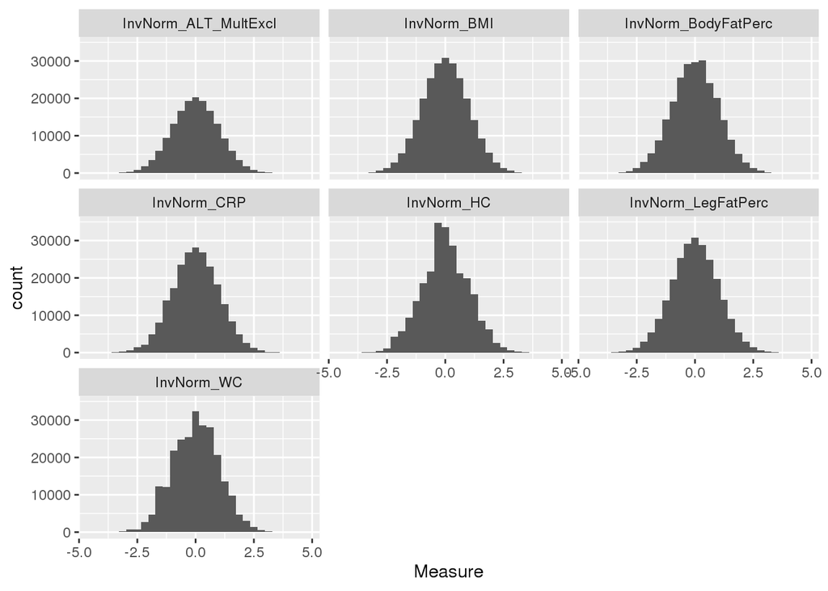

```r
#Histograms, InvNorm - female
female %>%
  select(InvNorm_BMI, InvNorm_WC, InvNorm_HC, InvNorm_LegFatPerc, InvNorm_BodyFatPerc, InvNorm_ALT_MultExcl, InvNorm_CRP) %>%
  gather(key = BodyComp, value = Measure) %>%
  ggplot(aes(x = Measure)) +
  geom_histogram() +
  facet_wrap(~BodyComp)
```

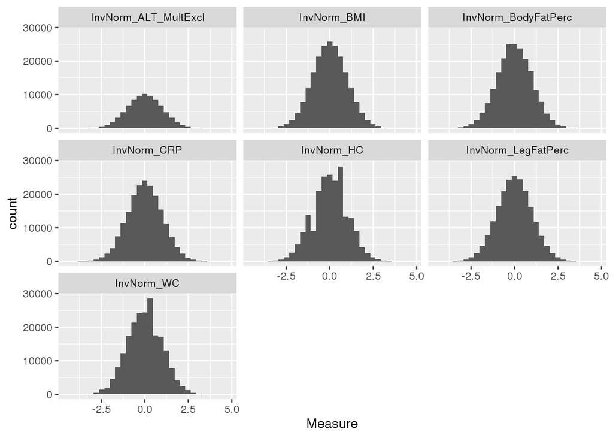

```r
#Histograms, InvNorm - male
male %>%
  select(InvNorm_BMI, InvNorm_WC, InvNorm_HC, InvNorm_LegFatPerc, InvNorm_BodyFatPerc, InvNorm_ALT_MultExcl, InvNorm_CRP) %>%
  gather(key = BodyComp, value = Measure) %>%
  ggplot(aes(x = Measure)) +
  geom_histogram() +
  facet_wrap(~BodyComp)
```

#Run regressions

```r
j = c("InvNorm_BMI", "InvNorm_WC", "InvNorm_HC", "InvNorm_LegFatPerc", "InvNorm_BodyFatPerc", "InvNorm_ALT_MultExcl", "InvNorm_CRP")
k = c("rs13389219_T.y", "snp7_130438531_C", "rs8126001_T", "rs998584_A.y")
covariates_f <- "Age_v0 + Age_sq + as.factor(female$f.54.0.0) + as.factor(female$chip) + PC1 + PC2 + PC3 + PC4 + PC5 + PC6 + PC7 + PC8 + PC9 + PC10"
covariates_m <- "Age_v0 + Age_sq + as.factor(male$f.54.0.0) + as.factor(male$chip) + PC1 + PC2 + PC3 + PC4 + PC5 + PC6 + PC7 + PC8 + PC9 + PC10"
params <- expand.grid(j, k, stringsAsFactors = FALSE)
params
```

```
##                    Var1             Var2
## 1           InvNorm_BMI   rs13389219_T.y
## 2            InvNorm_WC   rs13389219_T.y
## 3            InvNorm_HC   rs13389219_T.y
## 4    InvNorm_LegFatPerc   rs13389219_T.y
## 5   InvNorm_BodyFatPerc   rs13389219_T.y
## 6  InvNorm_ALT_MultExcl   rs13389219_T.y
## 7           InvNorm_CRP   rs13389219_T.y
## 8           InvNorm_BMI snp7_130438531_C
## 9            InvNorm_WC snp7_130438531_C
## 10           InvNorm_HC snp7_130438531_C
## 11   InvNorm_LegFatPerc snp7_130438531_C
## 12  InvNorm_BodyFatPerc snp7_130438531_C
## 13 InvNorm_ALT_MultExcl snp7_130438531_C
## 14          InvNorm_CRP snp7_130438531_C
## 15          InvNorm_BMI      rs8126001_T
## 16           InvNorm_WC      rs8126001_T
## 17           InvNorm_HC      rs8126001_T
## 18   InvNorm_LegFatPerc      rs8126001_T
## 19  InvNorm_BodyFatPerc      rs8126001_T
## 20 InvNorm_ALT_MultExcl      rs8126001_T
## 21          InvNorm_CRP      rs8126001_T
## 22          InvNorm_BMI     rs998584_A.y
## 23           InvNorm_WC     rs998584_A.y
## 24           InvNorm_HC     rs998584_A.y
## 25   InvNorm_LegFatPerc     rs998584_A.y
## 26  InvNorm_BodyFatPerc     rs998584_A.y
## 27 InvNorm_ALT_MultExcl     rs998584_A.y
## 28          InvNorm_CRP     rs998584_A.y
```

Females

```r
one_lm_female <- function(j, k) {

  form <- formula(paste0(j, "~ ", k, " + ", covariates_f))
  result <- lm(form, data = female)

  list(
    bodyComp = j,
    SNP = k,
    beta = coef(summary(result))[2,1],
    std_err  = coef(summary(result))[2,2],
    z_value  = coef(summary(result))[2,3],
    p_value  = coef(summary(result))[2,4],
    pct_2.5  = confint(result)[2,1],
    pct_97.5 = confint(result)[2,2],
    r_square = summary(result)$r.squared,
    n = length(residuals(result))
  )
}

result_list_female <- mapply(one_lm_female, params[,1], params[,2], SIMPLIFY = FALSE)

results_female <- do.call(rbind, result_list_female)
results_female
```

```
##                      bodyComp               SNP
## InvNorm_BMI          "InvNorm_BMI"          "rs13389219_T.y"
## InvNorm_WC           "InvNorm_WC"           "rs13389219_T.y"
## InvNorm_HC           "InvNorm_HC"           "rs13389219_T.y"
## InvNorm_LegFatPerc   "InvNorm_LegFatPerc"   "rs13389219_T.y"
## InvNorm_BodyFatPerc  "InvNorm_BodyFatPerc"  "rs13389219_T.y"
## InvNorm_ALT_MultExcl "InvNorm_ALT_MultExcl" "rs13389219_T.y"
## InvNorm_CRP          "InvNorm_CRP"          "rs13389219_T.y"
## InvNorm_BMI          "InvNorm_BMI"          "snp7_130438531_C"
## InvNorm_WC           "InvNorm_WC"           "snp7_130438531_C"
## InvNorm_HC           "InvNorm_HC"           "snp7_130438531_C"
## InvNorm_LegFatPerc   "InvNorm_LegFatPerc"   "snp7_130438531_C"
## InvNorm_BodyFatPerc  "InvNorm_BodyFatPerc"  "snp7_130438531_C"
## InvNorm_ALT_MultExcl "InvNorm_ALT_MultExcl" "snp7_130438531_C"
## InvNorm_CRP          "InvNorm_CRP"          "snp7_130438531_C"
## InvNorm_BMI          "InvNorm_BMI"          "rs8126001_T"
## InvNorm_WC           "InvNorm_WC"           "rs8126001_T"
## InvNorm_HC           "InvNorm_HC"           "rs8126001_T"
## InvNorm_LegFatPerc   "InvNorm_LegFatPerc"   "rs8126001_T"
## InvNorm_BodyFatPerc  "InvNorm_BodyFatPerc"  "rs8126001_T"
## InvNorm_ALT_MultExcl "InvNorm_ALT_MultExcl" "rs8126001_T"
## InvNorm_CRP          "InvNorm_CRP"          "rs8126001_T"
## InvNorm_BMI          "InvNorm_BMI"          "rs998584_A.y"
## InvNorm_WC           "InvNorm_WC"           "rs998584_A.y"
## InvNorm_HC           "InvNorm_HC"           "rs998584_A.y"
## InvNorm_LegFatPerc   "InvNorm_LegFatPerc"   "rs998584_A.y"
## InvNorm_BodyFatPerc  "InvNorm_BodyFatPerc"  "rs998584_A.y"
## InvNorm_ALT_MultExcl "InvNorm_ALT_MultExcl" "rs998584_A.y"
## InvNorm_CRP          "InvNorm_CRP"          "rs998584_A.y"
##                      beta         std_err     z_value    p_value
## InvNorm_BMI          0.01392997   0.002876956 4.841914   1.286719e-06
## InvNorm_WC           -0.009988101 0.002863725 -3.4878    0.0004870968
## InvNorm_HC           0.03211589   0.002888903 11.11699   1.053477e-28
## InvNorm_LegFatPerc   0.01755027   0.002820335 6.22276    4.892708e-10
## InvNorm_BodyFatPerc  0.02506435   0.002859578 8.765054   1.878434e-18
## InvNorm_ALT_MultExcl -0.03003635  0.003512181 -8.552051  1.219418e-17
## InvNorm_CRP          0.00912484   0.002995719 3.04596    0.002319657
## InvNorm_BMI          -0.006587855 0.002823866 -2.33292   0.01965312
## InvNorm_WC           -0.001659147 0.0028112   -0.5901916 0.5550627
## InvNorm_HC           -0.02483225  0.002836527 -8.754456  2.063502e-18
```

[output cut: 32 more lines]

```
## InvNorm_CRP          -0.009218182 0.002312505  0.03080206  224084
## InvNorm_BMI          0.003300524  0.01438085   0.02081914  245529
## InvNorm_WC           -0.008374955 0.002656728  0.02709668  245838
## InvNorm_HC           0.007913906  0.01904437   0.009119571 245823
## InvNorm_LegFatPerc   -0.001816832 0.009047852  0.0707649   242265
## InvNorm_BodyFatPerc  -0.002756732 0.008260093  0.04450505  242293
## InvNorm_ALT_MultExcl -0.0146072   -0.001086512 0.03919739  161459
## InvNorm_CRP          -0.02393982  -0.01240062  0.030941    223832
## InvNorm_BMI          -0.01444432  -0.003365772 0.0208513   245760
## InvNorm_WC           0.01795696   0.02898248   0.02735975  246068
## InvNorm_HC           -0.02341447  -0.01228772  0.009182747 246053
## InvNorm_LegFatPerc   -0.004467989 0.006395567  0.07080087  242485
## InvNorm_BodyFatPerc  -0.01247376  -0.001457395 0.04461551  242513
## InvNorm_ALT_MultExcl 0.01343579   0.02697332   0.03935487  161550
## InvNorm_CRP          -0.005275638 0.006266534  0.03091414  224053
```

```r
df_female <- data.frame(matrix(unlist(results_female), nrow = 28, ncol = 10, byrow = F),stringsAsFactors=FALSE)
str(df_female)
```

```
## 'data.frame':    28 obs. of  10 variables:
##  $ X1 : chr  "InvNorm_BMI" "InvNorm_WC" "InvNorm_HC" "InvNorm_LegFatPerc" ...
##  $ X2 : chr  "rs13389219_T.y" "rs13389219_T.y" "rs13389219_T.y" "rs13389219_T.y" ...
##  $ X3 : chr  "0.0139299725974801" "-0.00998810056999326" "0.0321158924638989" "0.0175502690425593" ...
##  $ X4 : chr  "0.00287695609765549" "0.00286372533284593" "0.00288890277140178" "0.00282033521886507" ...
##  $ X5 : chr  "4.84191351019643" "-3.48779977445226" "11.1169862765286" "6.22275994894738" ...
##  $ X6 : chr  "1.28671908735789e-06" "0.000487096754120453" "1.05347744121142e-28" "4.8927079523926e-10" ...
##  $ X7 : chr  "0.00829121476915806" "-0.01560092641502" "0.0264537195041255" "0.0120224862749751" ...
##  $ X8 : chr  "0.0195687304258021" "-0.0043752747249665" "0.0377780654236723" "0.0230780518101436" ...
##  $ X9 : chr  "0.0209326887016982" "0.027179507665349" "0.00954839067032187" "0.0710560203035531" ...
##  $ X10: chr  "248290" "248602" "248587" "244986" ...
```

```r
names(df_female) <- c("bodyComp", "SNP","beta", "stdErr", "zvalue", "pvalue", "confint2.5", "confint97.5", "rsquare", "n")
str(df_female)
```

```
## 'data.frame':    28 obs. of  10 variables:
##  $ bodyComp   : chr  "InvNorm_BMI" "InvNorm_WC" "InvNorm_HC" "InvNorm_LegFatPerc" ...
##  $ SNP        : chr  "rs13389219_T.y" "rs13389219_T.y" "rs13389219_T.y" "rs13389219_T.y" ...
##  $ beta       : chr  "0.0139299725974801" "-0.00998810056999326" "0.0321158924638989" "0.0175502690425593" ...
##  $ stdErr     : chr  "0.00287695609765549" "0.00286372533284593" "0.00288890277140178" "0.00282033521886507" ...
##  $ zvalue     : chr  "4.84191351019643" "-3.48779977445226" "11.1169862765286" "6.22275994894738" ...
##  $ pvalue     : chr  "1.28671908735789e-06" "0.000487096754120453" "1.05347744121142e-28" "4.8927079523926e-10" ...
##  $ confint2.5 : chr  "0.00829121476915806" "-0.01560092641502" "0.0264537195041255" "0.0120224862749751" ...
##  $ confint97.5: chr  "0.0195687304258021" "-0.0043752747249665" "0.0377780654236723" "0.0230780518101436" ...
##  $ rsquare    : chr  "0.0209326887016982" "0.027179507665349" "0.00954839067032187" "0.0710560203035531" ...
##  $ n          : chr  "248290" "248602" "248587" "244986" ...
```

```r
df_female$Sex <- 'Female'
```

Males

```r
one_lm_male <- function(j, k) {

  form <- formula(paste0(j, "~ ", k, " + ", covariates_m))
  result <- lm(form, data = male)

  list(
    bodyComp = j,
    SNP = k,
    beta = coef(summary(result))[2,1],
    std_err  = coef(summary(result))[2,2],
    z_value  = coef(summary(result))[2,3],
    p_value  = coef(summary(result))[2,4],
    pct_2.5  = confint(result)[2,1],
    pct_97.5 = confint(result)[2,2],
    r_square = summary(result)$r.squared,
    n = length(residuals(result))

  )
}

result_list_male <- mapply(one_lm_male, params[,1], params[,2], SIMPLIFY = FALSE)

results_male <- do.call(rbind, result_list_male)
results_male
```

```
##                      bodyComp               SNP
## InvNorm_BMI          "InvNorm_BMI"          "rs13389219_T.y"
## InvNorm_WC           "InvNorm_WC"           "rs13389219_T.y"
## InvNorm_HC           "InvNorm_HC"           "rs13389219_T.y"
## InvNorm_LegFatPerc   "InvNorm_LegFatPerc"   "rs13389219_T.y"
## InvNorm_BodyFatPerc  "InvNorm_BodyFatPerc"  "rs13389219_T.y"
## InvNorm_ALT_MultExcl "InvNorm_ALT_MultExcl" "rs13389219_T.y"
## InvNorm_CRP          "InvNorm_CRP"          "rs13389219_T.y"
## InvNorm_BMI          "InvNorm_BMI"          "snp7_130438531_C"
## InvNorm_WC           "InvNorm_WC"           "snp7_130438531_C"
## InvNorm_HC           "InvNorm_HC"           "snp7_130438531_C"
## InvNorm_LegFatPerc   "InvNorm_LegFatPerc"   "snp7_130438531_C"
## InvNorm_BodyFatPerc  "InvNorm_BodyFatPerc"  "snp7_130438531_C"
## InvNorm_ALT_MultExcl "InvNorm_ALT_MultExcl" "snp7_130438531_C"
## InvNorm_CRP          "InvNorm_CRP"          "snp7_130438531_C"
## InvNorm_BMI          "InvNorm_BMI"          "rs8126001_T"
## InvNorm_WC           "InvNorm_WC"           "rs8126001_T"
## InvNorm_HC           "InvNorm_HC"           "rs8126001_T"
## InvNorm_LegFatPerc   "InvNorm_LegFatPerc"   "rs8126001_T"
## InvNorm_BodyFatPerc  "InvNorm_BodyFatPerc"  "rs8126001_T"
## InvNorm_ALT_MultExcl "InvNorm_ALT_MultExcl" "rs8126001_T"
## InvNorm_CRP          "InvNorm_CRP"          "rs8126001_T"
## InvNorm_BMI          "InvNorm_BMI"          "rs998584_A.y"
## InvNorm_WC           "InvNorm_WC"           "rs998584_A.y"
## InvNorm_HC           "InvNorm_HC"           "rs998584_A.y"
## InvNorm_LegFatPerc   "InvNorm_LegFatPerc"   "rs998584_A.y"
## InvNorm_BodyFatPerc  "InvNorm_BodyFatPerc"  "rs998584_A.y"
## InvNorm_ALT_MultExcl "InvNorm_ALT_MultExcl" "rs998584_A.y"
## InvNorm_CRP          "InvNorm_CRP"          "rs998584_A.y"
##                      beta         std_err     z_value    p_value
## InvNorm_BMI          0.003374239  0.003149589 1.071327   0.2840237
## InvNorm_WC           0.01205652   0.003128207 3.85413    0.0001161766
## InvNorm_HC           0.01040654   0.003146481 3.307358   0.0009419625
## InvNorm_LegFatPerc   0.01708296   0.003096733 5.516444   3.463418e-08
## InvNorm_BodyFatPerc  0.02059736   0.003106487 6.630434   3.355251e-11
## InvNorm_ALT_MultExcl -0.0235148   0.00497566  -4.725966  2.294005e-06
## InvNorm_CRP          0.007034401  0.003270251 2.151028   0.03147523
## InvNorm_BMI          -0.007966959 0.003098166 -2.571509  0.01012634
## InvNorm_WC           -0.01313484  0.003076615 -4.26925   1.962184e-05
## InvNorm_HC           -0.009776019 0.003094894 -3.158757  0.001584662
```

[output cut: 32 more lines]

```
## InvNorm_CRP          -0.01180173   0.000808963  0.01986173  190193
## InvNorm_BMI          -0.0005345218 0.0115965    0.01178155  206636
## InvNorm_WC           -0.002931115  0.009114785  0.02209761  207010
## InvNorm_HC           -0.001395453  0.01072343   0.009065122 206979
## InvNorm_LegFatPerc   -0.007014955  0.004914426  0.05909547  203427
## InvNorm_BodyFatPerc  -0.008049415  0.003918257  0.05394873  203208
## InvNorm_ALT_MultExcl -0.02297666   -0.003859282 0.02974634  81644
## InvNorm_CRP          -0.01497728   -0.002378929 0.01989981  189993
## InvNorm_BMI          -0.02254912   -0.01042775  0.01187648  206804
## InvNorm_WC           -0.01650375   -0.004465242 0.02197399  207180
## InvNorm_HC           -0.03545439   -0.02334619  0.009417191 207149
## InvNorm_LegFatPerc   -0.02050028   -0.008589015 0.05936878  203596
## InvNorm_BodyFatPerc  -0.02563206   -0.01367946  0.05420649  203379
## InvNorm_ALT_MultExcl 0.001651507   0.02074186   0.0297941   81719
## InvNorm_CRP          -0.01011035   0.002481168  0.01985041  190141
```

```r
df_male <- data.frame(matrix(unlist(results_male), nrow = 28, ncol = 10, byrow = F),stringsAsFactors=FALSE)
str(df_male)
```

```
## 'data.frame':    28 obs. of  10 variables:
##  $ X1 : chr  "InvNorm_BMI" "InvNorm_WC" "InvNorm_HC" "InvNorm_LegFatPerc" ...
##  $ X2 : chr  "rs13389219_T.y" "rs13389219_T.y" "rs13389219_T.y" "rs13389219_T.y" ...
##  $ X3 : chr  "0.00337423871974843" "0.0120565168706296" "0.0104065391794535" "0.0170829569282966" ...
##  $ X4 : chr  "0.00314958852103725" "0.00312820727417863" "0.00314648085424778" "0.0030967332568691" ...
##  $ X5 : chr  "1.0713268407002" "3.85412979828687" "3.30735817616833" "5.51644443072506" ...
##  $ X6 : chr  "0.284023733168808" "0.000116176626729547" "0.000941962530933961" "3.46341756800887e-08" ...
##  $ X7 : chr  "-0.00279887712005875" "0.0059253078116383" "0.00423951434902871" "0.0110134355480811" ...
##  $ X8 : chr  "0.00954735455955561" "0.0181877259296209" "0.0165735640098783" "0.0231524783085122" ...
##  $ X9 : chr  "0.0117764842817836" "0.0220705693243529" "0.00906017183776212" "0.0593273439923129" ...
##  $ X10: chr  "208904" "209282" "209250" "205660" ...
```

```r
names(df_male) <- c("bodyComp", "SNP","beta", "stdErr", "zvalue", "pvalue", "confint2.5", "confint97.5", "rsquare", "n")
str(df_male)
```

```
## 'data.frame':    28 obs. of  10 variables:
##  $ bodyComp   : chr  "InvNorm_BMI" "InvNorm_WC" "InvNorm_HC" "InvNorm_LegFatPerc" ...
##  $ SNP        : chr  "rs13389219_T.y" "rs13389219_T.y" "rs13389219_T.y" "rs13389219_T.y" ...
##  $ beta       : chr  "0.00337423871974843" "0.0120565168706296" "0.0104065391794535" "0.0170829569282966" ...
##  $ stdErr     : chr  "0.00314958852103725" "0.00312820727417863" "0.00314648085424778" "0.0030967332568691" ...
##  $ zvalue     : chr  "1.0713268407002" "3.85412979828687" "3.30735817616833" "5.51644443072506" ...
##  $ pvalue     : chr  "0.284023733168808" "0.000116176626729547" "0.000941962530933961" "3.46341756800887e-08" ...
##  $ confint2.5 : chr  "-0.00279887712005875" "0.0059253078116383" "0.00423951434902871" "0.0110134355480811" ...
##  $ confint97.5: chr  "0.00954735455955561" "0.0181877259296209" "0.0165735640098783" "0.0231524783085122" ...
##  $ rsquare    : chr  "0.0117764842817836" "0.0220705693243529" "0.00906017183776212" "0.0593273439923129" ...
##  $ n          : chr  "208904" "209282" "209250" "205660" ...
```

```r
df_male$Sex <- 'Male'
```

Combine male and female results, WHR increasing allele, name changes, save

```r
setwd('/rsgrps/yann/michellenewell/UKB/Other/Fat_4SNPs_Regression_20191004/results')
full_results <- rbind(df_female, df_male)
```

```r
rm(df_female)
rm(df_male)
```

If full_results from list, Rename .y SNPs, split rs number from allele, set WHR increasing allele and change outcomes accordingly

```r
#convert numers into numeric
full_results$beta <- as.numeric(full_results$beta)
full_results$stdErr <- as.numeric(full_results$stdErr)
full_results$zvalue <- as.numeric(full_results$zvalue)
full_results$pvalue <- as.numeric(full_results$pvalue)
full_results$confint2.5 <- as.numeric(full_results$confint2.5)
full_results$confint97.5 <- as.numeric(full_results$confint97.5)
full_results$bodyComp <- as.character(full_results$bodyComp)
full_results$SNP <- as.character(full_results$SNP)
full_results$Sex <- as.character(full_results$Sex)
full_results$rsquare <- as.numeric(full_results$rsquare)
full_results$n <- as.numeric(full_results$n)
str(full_results)
```

```
## 'data.frame':    56 obs. of  11 variables:
##  $ bodyComp   : chr  "InvNorm_BMI" "InvNorm_WC" "InvNorm_HC" "InvNorm_LegFatPerc" ...
##  $ SNP        : chr  "rs13389219_T.y" "rs13389219_T.y" "rs13389219_T.y" "rs13389219_T.y" ...
##  $ beta       : num  0.01393 -0.00999 0.03212 0.01755 0.02506 ...
##  $ stdErr     : num  0.00288 0.00286 0.00289 0.00282 0.00286 ...
##  $ zvalue     : num  4.84 -3.49 11.12 6.22 8.77 ...
##  $ pvalue     : num  1.29e-06 4.87e-04 1.05e-28 4.89e-10 1.88e-18 ...
##  $ confint2.5 : num  0.00829 -0.0156 0.02645 0.01202 0.01946 ...
##  $ confint97.5: num  0.01957 -0.00438 0.03778 0.02308 0.03067 ...
##  $ rsquare    : num  0.02093 0.02718 0.00955 0.07106 0.04497 ...
##  $ n          : num  248290 248602 248587 244986 245014 ...
##  $ Sex        : chr  "Female" "Female" "Female" "Female" ...
```

```r
#rename column bodyComps are outcome
names(full_results)[names(full_results) == "bodyComp"] <- "outcome"
```

```r
#rename some snps
full_results$SNP <- ifelse((full_results$SNP == 'rs13389219_T.y'), 'rs13389219_T', full_results$SNP)
full_results$SNP <- ifelse((full_results$SNP == 'snp7_130438531_C'), 'chr7_130438531_CT', full_results$SNP)
full_results$SNP <- ifelse((full_results$SNP == 'rs998584_A.y'), 'rs998584_A', full_results$SNP)
```

Adjust for WHR increasing allele

```r
#_____________label with closest gene___________
full_results$Gene <- NA
full_results$Gene[full_results$SNP == "rs13389219_T"] <- "GRB14-COBBL1"
full_results$Gene[full_results$SNP == "rs8126001_T"] <- "RGS19/OPRL1"
full_results$Gene[full_results$SNP == "chr7_130438531_CT"] <- "KLF14"
full_results$Gene[full_results$SNP == "rs998584_A"] <- "VEGFA"
```

```r
#WHR increasing alleles
#beta
full_results$beta_WHRinc <- NA
full_results$beta_WHRinc[full_results$SNP == "rs13389219_T"] <- (full_results$beta[full_results$SNP == "rs13389219_T"]*(-1))
full_results$beta_WHRinc[full_results$SNP == "rs8126001_T"] <- (full_results$beta[full_results$SNP == "rs8126001_T"]*(-1))
full_results$beta_WHRinc[full_results$SNP == "chr7_130438531_CT"] <- full_results$beta[full_results$SNP == "chr7_130438531_CT"]
full_results$beta_WHRinc[full_results$SNP == "rs998584_A"] <- full_results$beta[full_results$SNP == "rs998584_A"]

#ciHigh
full_results$ciHigh_WHRinc <- NA
full_results$ciHigh_WHRinc[full_results$SNP == "rs13389219_T"] <- (full_results$confint97.5[full_results$SNP == "rs13389219_T"]*(-1))
full_results$ciHigh_WHRinc[full_results$SNP == "rs8126001_T"] <- (full_results$confint97.5[full_results$SNP == "rs8126001_T"]*(-1))
full_results$ciHigh_WHRinc[full_results$SNP == "chr7_130438531_CT"] <- full_results$confint97.5[full_results$SNP == "chr7_130438531_CT"]
full_results$ciHigh_WHRinc[full_results$SNP == "rs998584_A"] <- full_results$confint97.5[full_results$SNP == "rs998584_A"]

#ciLow
full_results$ciLow_WHRinc <- NA
full_results$ciLow_WHRinc[full_results$SNP == "rs13389219_T"] <- (full_results$confint2.5[full_results$SNP == "rs13389219_T"]*(-1))
full_results$ciLow_WHRinc[full_results$SNP == "rs8126001_T"] <- (full_results$confint2.5[full_results$SNP == "rs8126001_T"]*(-1))
full_results$ciLow_WHRinc[full_results$SNP == "chr7_130438531_CT"] <- full_results$confint2.5[full_results$SNP == "chr7_130438531_CT"]
full_results$ciLow_WHRinc[full_results$SNP == "rs998584_A"] <- full_results$confint2.5[full_results$SNP == "rs998584_A"]
```

Save final data

```r
setwd('/rsgrps/yann/michellenewell/UKB/Other/Fat_4SNPs_Regression_20191004/results')
write.csv(full_results, "20200316_FinalRegResults_4snpsWTraits_WhitesOnly.csv", row.names = F, quote = F)
```

Let’s make some plots!

CRP for male and female only, no combined

```r
#________________order body comps________________________
full_results$outcome <- factor(full_results$outcome,
                               levels = c("InvNorm_CRP", "InvNorm_ALT_MultExcl", "InvNorm_LegFatPerc", "InvNorm_BodyFatPerc",
                                          "InvNorm_HC", "InvNorm_WC", "InvNorm_BMI"))
full_results$Gene <- factor(full_results$Gene, levels = c("VEGFA", "GRB14-COBBL1", "KLF14", "RGS19/OPRL1"))

full_results$Sex <- factor(full_results$Sex, levels = c("Female", "Male"))
```

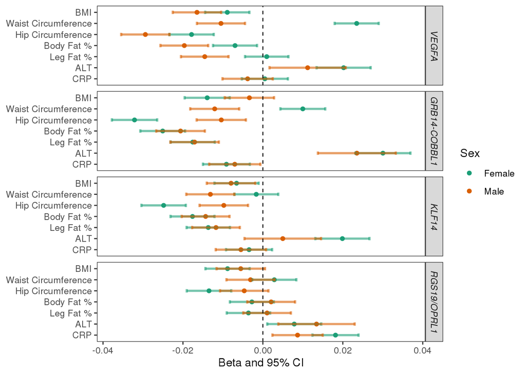

```r
setwd('/rsgrps/yann/michellenewell/UKB/Other/Fat_4SNPs_Regression_20191004/figures')
library(RColorBrewer)

#_____________test new plot by Gene___________
ggplot(data=full_results, aes(x=outcome, y=beta_WHRinc, color=Sex)) +
  geom_point() +
  ylab("Beta and 95% CI") + xlab(NULL) +
  facet_grid(Gene ~ .) +
  scale_x_discrete(labels = c("InvNorm_CRP" = "CRP", "InvNorm_ALT_MultExcl" = "ALT", "InvNorm_LegFatPerc" = "Leg Fat %", "InvNorm_BodyFatPerc" = "Body Fat %",
                              "InvNorm_BMI" = "BMI", "InvNorm_HC" = "Hip Circumference", "InvNorm_WC" =  "Waist Circumference")) +
  scale_colour_brewer(palette = "Dark2") +
  theme_bw()+
  geom_errorbar(aes(ymin=ciLow_WHRinc, ymax=ciHigh_WHRinc), size = 1, width=0.3, alpha = 0.6, show.legend=FALSE)+
  geom_hline(yintercept=0, lty = 'dashed', size = 0.4) +
  theme(panel.grid.major = element_blank(), panel.grid.minor = element_blank())+
  coord_flip() +
  theme(strip.text = element_text(face = "italic"))
```

```r
ggsave("20200316_Updated4SNPsCardioTraits_BodyCompBySNP_CRPbySexOnly_WHRinc_WhitesOnly.png", width=6, height=8, dpi=300)
```